# Time Series Project

Aaron Abromowitz and Alex Thibeaux

2024-11-16

# Libraries

```r
library(tidyverse)
library(tswge)
library(vars)
library(lubridate)
library(vars)
```

# Load Data

```r
# Variable of Interest - Quarterly from 1/1/63
file_path = "https://raw.githubusercontent.com/aabromowitz/TimeSeriersProject/refs/heads/main/MSPUS.csv"
mhp <- read.csv(file_path, header = TRUE)

# Home ownership rate - Quarterly from 1/1/65
file_path = "https://raw.githubusercontent.com/aabromowitz/TimeSeriersProject/refs/heads/main/RHORUSQ156N.csv"
hor <- read.csv(file_path, header = TRUE)

# Housing units completed - Monthly from 1/1/1968
file_path = "https://raw.githubusercontent.com/aabromowitz/TimeSeriersProject/refs/heads/main/COMPUTSA.csv"
huc <- read.csv(file_path, header = TRUE)

# Supply of new houses - Monthly from 1/1/1963
file_path = "https://raw.githubusercontent.com/aabromowitz/TimeSeriersProject/refs/heads/main/MSACSR.csv"
snh <- read.csv(file_path, header = TRUE)

# House price index - Quarterly from 1/1/1975
file_path = "https://raw.githubusercontent.com/aabromowitz/TimeSeriersProject/refs/heads/main/USSTHPI.csv"
hpi <- read.csv(file_path, header = TRUE)

# Converting Monthly Data to Quarterly Data

# Preserve Monthly format
snh_monthly <- snh
huc_monthly <- huc

# Supply of New Houses Variable
snh$DATE = as.Date(snh$DATE)
snh$month <- month(snh$DATE)
head(snh)
```

```
##         DATE MSACSR month
## 1 1963-01-01    4.7     1
## 2 1963-02-01    6.6     2
## 3 1963-03-01    6.4     3
## 4 1963-04-01    5.3     4
## 5 1963-05-01    5.1     5
## 6 1963-06-01    6.0     6
```

```r
snh_quarterly <- snh %>%
  filter(snh$month == 1 | snh$month == 4 | snh$month == 7 | snh$month == 10)
summary(snh_quarterly)
```

```
##       DATE                MSACSR           month
##  Min.   :1963-01-01   Min.   : 3.300   Min.   : 1.000
##  1st Qu.:1978-05-16   1st Qu.: 4.900   1st Qu.: 2.500
##  Median :1993-10-01   Median : 5.800   Median : 4.000
##  Mean   :1993-09-30   Mean   : 6.117   Mean   : 5.482
##  3rd Qu.:2009-02-15   3rd Qu.: 6.950   3rd Qu.: 7.000
##  Max.   :2024-07-01   Max.   :12.200   Max.   :10.000
```

```r
# Housing Units Completed Variable
huc$DATE = as.Date(huc$DATE)
huc$month <- month(huc$DATE)
head(huc)
```

```
##         DATE COMPUTSA month
## 1 1968-01-01     1257     1
## 2 1968-02-01     1174     2
## 3 1968-03-01     1323     3
## 4 1968-04-01     1328     4
## 5 1968-05-01     1367     5
## 6 1968-06-01     1184     6
```

```r
huc_quarterly <- huc %>%
  filter(huc$month == 1 | huc$month == 4 | huc$month == 7 | huc$month == 10)
summary(huc_quarterly)
```

```
##       DATE               COMPUTSA        month
##  Min.   :1968-01-01   Min.   : 520   Min.   : 1.00
##  1st Qu.:1982-02-15   1st Qu.:1196   1st Qu.: 2.50
##  Median :1996-04-01   Median :1389   Median : 4.00
##  Mean   :1996-03-31   Mean   :1394   Mean   : 5.48
##  3rd Qu.:2010-05-16   3rd Qu.:1632   3rd Qu.: 7.00
##  Max.   :2024-07-01   Max.   :2195   Max.   :10.00
```

```r
# Using same time frames, which would be starting at 1975 Q1 and ending at 2024 Q2 (due to hpi data)

# hor observation 41 is 1975 Q1
hor_1975 = hor[41:238,]
hor_1975$DATE <- as.Date(hor_1975$DATE)
summary(hor_1975)
```

```
##       DATE             RHORUSQ156N
##  Min.   :1975-01-01   Min.   :62.90
##  1st Qu.:1987-04-23   1st Qu.:64.20
##  Median :1999-08-16   Median :65.15
##  Mean   :1999-08-16   Mean   :65.53
##  3rd Qu.:2011-12-09   3rd Qu.:66.58
##  Max.   :2024-04-01   Max.   :69.20
```

```r
# huc_quarterlly observation 29
huc_1975 = huc_quarterly[29:226,]
summary(huc_1975)
```

```
##       DATE               COMPUTSA        month
##  Min.   :1975-01-01   Min.   : 520   Min.   : 1.00
##  1st Qu.:1987-04-23   1st Qu.:1136   1st Qu.: 1.75
##  Median :1999-08-16   Median :1378   Median : 4.00
##  Mean   :1999-08-16   Mean   :1355   Mean   : 5.47
##  3rd Qu.:2011-12-09   3rd Qu.:1599   3rd Qu.: 7.00
##  Max.   :2024-04-01   Max.   :2071   Max.   :10.00
```

```r
# mhp observation 49 is 1975 Q1
mhp_1975 = mhp[49:246,]
mhp_1975$DATE <- as.Date(mhp_1975$DATE)
summary(mhp_1975)
```

```
##       DATE                MSPUS
##  Min.   :1975-01-01   Min.   : 38100
##  1st Qu.:1987-04-23   1st Qu.:104050
##  Median :1999-08-16   Median :161150
##  Mean   :1999-08-16   Mean   :185330
##  3rd Qu.:2011-12-09   3rd Qu.:247350
##  Max.   :2024-04-01   Max.   :442600
```

```r
# snh_quarterly observation 49 is 1975 Q1
snh_1975 = snh_quarterly[49:246,]
summary(snh_1975)
```

```
##       DATE                MSACSR           month
##  Min.   :1975-01-01   Min.   : 3.300   Min.   : 1.00
##  1st Qu.:1987-04-23   1st Qu.: 4.900   1st Qu.: 1.75
##  Median :1999-08-16   Median : 6.000   Median : 4.00
##  Mean   :1999-08-16   Mean   : 6.167   Mean   : 5.47
##  3rd Qu.:2011-12-09   3rd Qu.: 7.075   3rd Qu.: 7.00
##  Max.   :2024-04-01   Max.   :12.200   Max.   :10.00
```

```r
# Housing Price Index variable already from 1975 Q1 - 2024 Q2
hpi$DATE <- as.Date(hpi$DATE)
summary(hpi)
```

```
##       DATE               USSTHPI
##  Min.   :1975-01-01   Min.   : 60.03
##  1st Qu.:1987-04-23   1st Qu.:145.09
##  Median :1999-08-16   Median :224.69
##  Mean   :1999-08-16   Mean   :260.08
##  3rd Qu.:2011-12-09   3rd Qu.:351.31
##  Max.   :2024-04-01   Max.   :682.18
```

```r
# Create Dataframe
# Combined (Train/Test) Set NOT LOGGED
fed_housing_data_NL = data.frame(Year_Quarter = mhp_1975$DATE, Ownership_Rate = hor_1975$RHORUSQ156N, Housing_Units_Completed = huc_1975$COMPUTSA, Supply_New_Houses = snh_1975$MSACSR, Housing_Price_Index = hpi$USSTHPI, Median_Sales_Price = mhp_1975$MSPUS)

# Combined (Train/Test) Set LOGGED
fed_housing_data = data.frame(Year_Quarter = as.Date(mhp_1975$DATE), Ownership_Rate = hor_1975$RHORUSQ156N, Housing_Units_Completed = huc_1975$COMPUTSA, Supply_New_Houses = snh_1975$MSACSR, Housing_Price_Index = hpi$USSTHPI, Median_Sales_Price = log(mhp_1975$MSPUS))

# Train & Test sets
train = fed_housing_data[1:168,]
test = fed_housing_data[169:198,]

summary(fed_housing_data)
```

```
##   Year_Quarter        Ownership_Rate  Housing_Units_Completed Supply_New_Houses
##  Min.   :1975-01-01   Min.   :62.90   Min.   : 520            Min.   : 3.300
##  1st Qu.:1987-04-23   1st Qu.:64.20   1st Qu.:1136            1st Qu.: 4.900
##  Median :1999-08-16   Median :65.15   Median :1378            Median : 6.000
##  Mean   :1999-08-16   Mean   :65.53   Mean   :1355            Mean   : 6.167
##  3rd Qu.:2011-12-09   3rd Qu.:66.58   3rd Qu.:1599            3rd Qu.: 7.075
##  Max.   :2024-04-01   Max.   :69.20   Max.   :2071            Max.   :12.200
##  Housing_Price_Index Median_Sales_Price
##  Min.   : 60.03      Min.   :10.55
##  1st Qu.:145.09      1st Qu.:11.55
##  Median :224.69      Median :11.99
##  Mean   :260.08      Mean   :11.95
##  3rd Qu.:351.31      3rd Qu.:12.42
##  Max.   :682.18      Max.   :13.00
```

# EDA

## Median Housing Sale Price

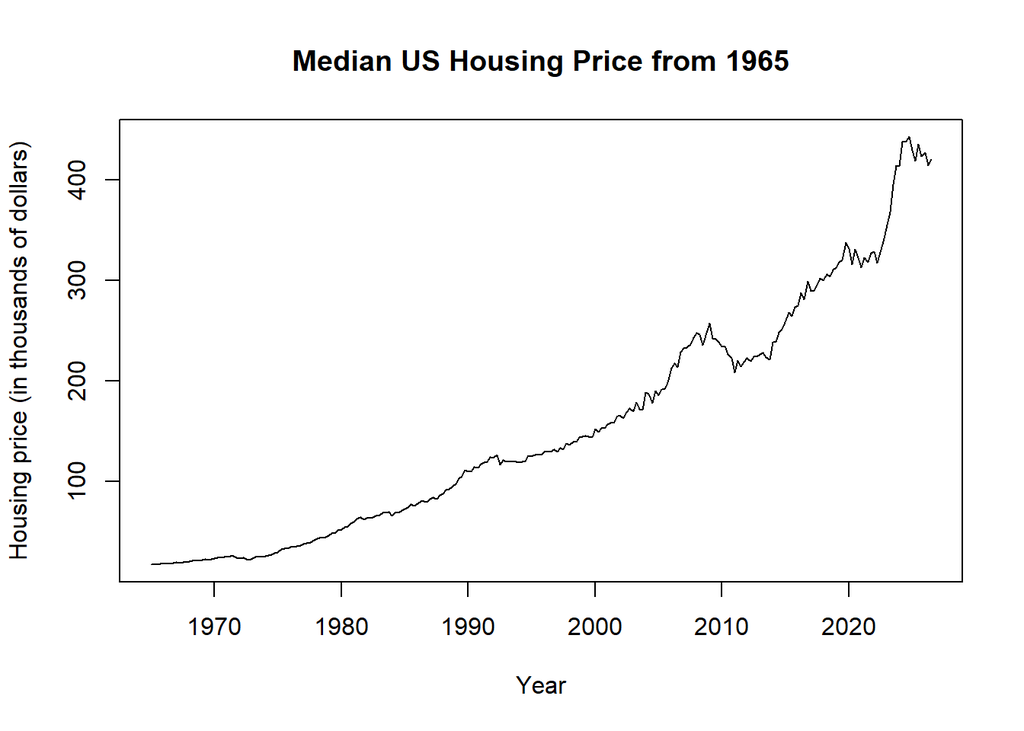

```r
mhp=mhp$MSPUS
plot(ts(mhp/1000, frequency=4,start=c(1965,1)),xlab='Year',ylab='Housing price (in thousands of dollars)')
title(main='Median US Housing Price from 1965')
```

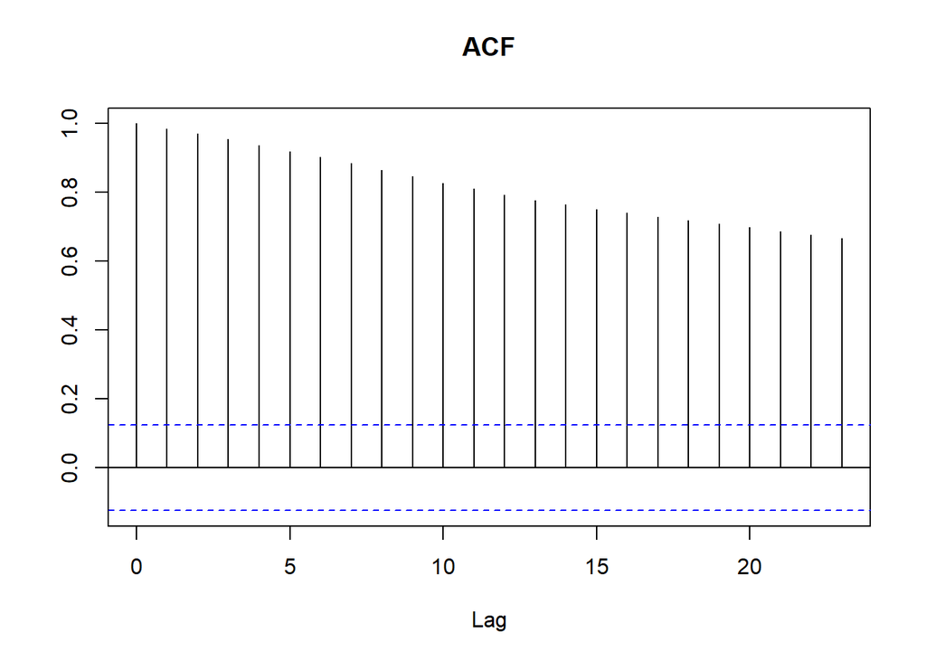

```r
acf(mhp,ylab='',main='ACF')
```

```r
x = parzen.wge(mhp)
```

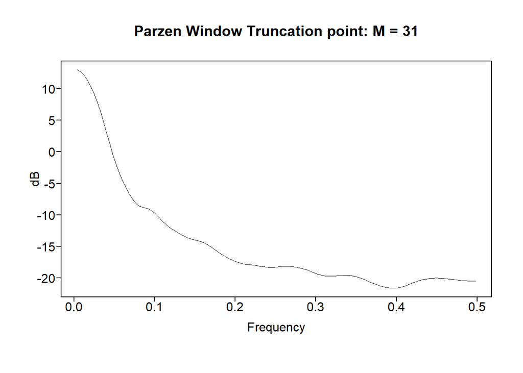

The realization looks like it is increasing linearly. This data could be model with a signal plus noise, with a linear signal.

The realization appears to be non stationary. There is evidence that the data is increasing over time. In addition, the variation appears much higher in later years as in earlier years, showing that variance is increasing over time as well. When modeling, it may be useful to take the logarithm of the data before modeling.

The ACF shows very slowly dampening autocorrelations. The parzen window also shows a very low frequency. This could points to a (1-B) term which could be removed with a high-pass difference filter.

## Home Ownership Rate

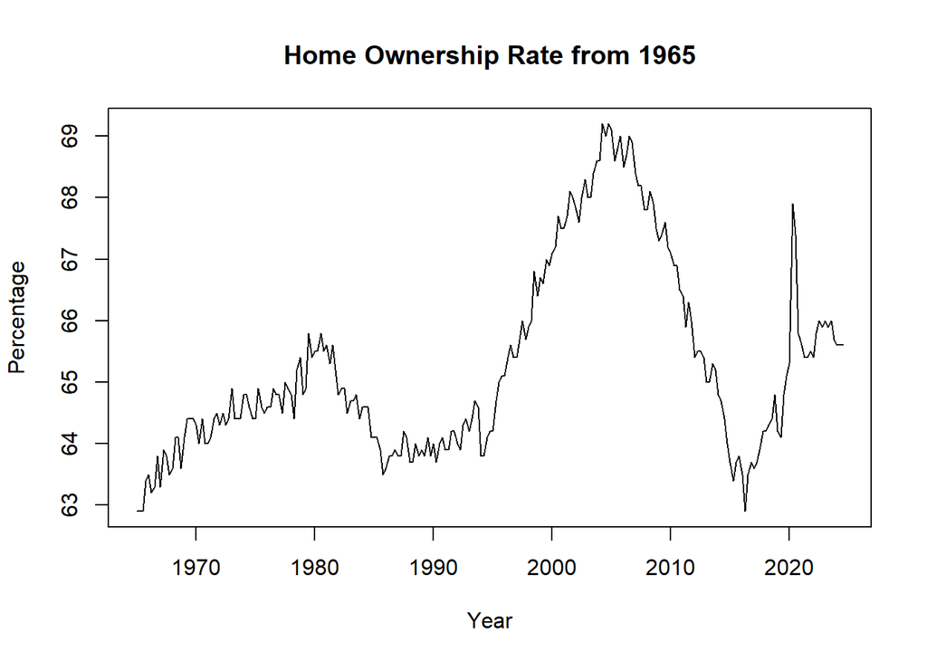

```r
hor <- hor$RHORUSQ156N
plot(ts(hor, frequency=4,start=c(1965,1)),xlab='Year',ylab='Percentage')
title(main='Home Ownership Rate from 1965')
```

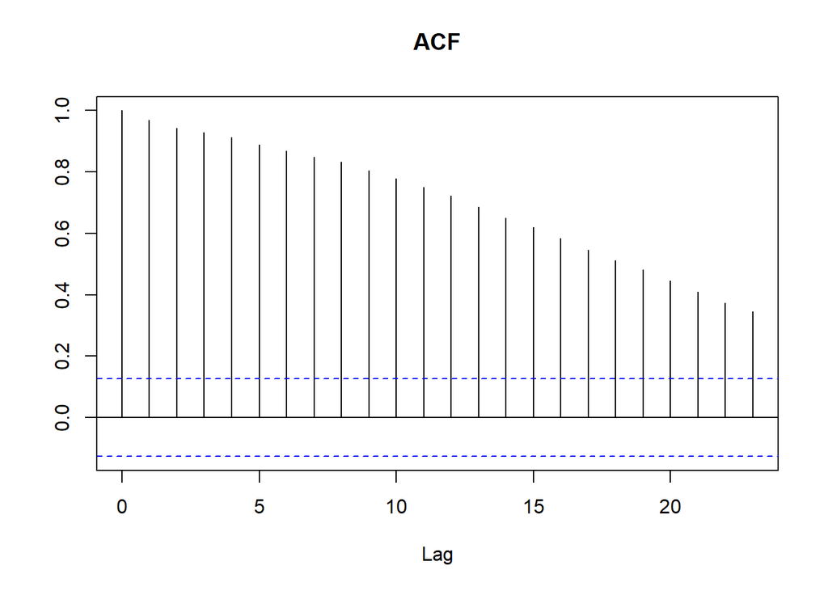

```r
acf(hor,ylab='',main='ACF')
```

```r
x = parzen.wge(hor)
```

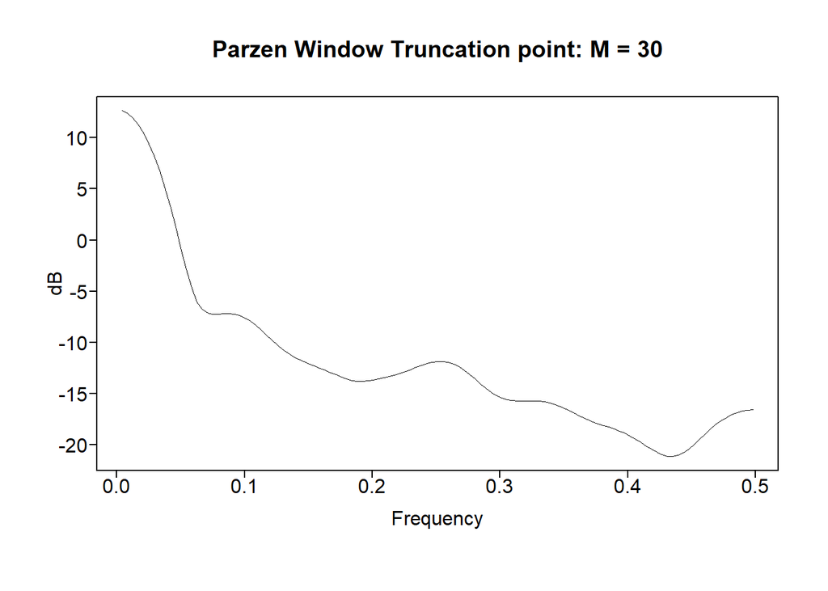

Unlike the median house price, the home ownership rate appears to be stationary. There isn’t a linear trend to the data, and the variance seems to be constant over time.

The ACF does show that there are dampening autocorrelations, but not quite at the rate as for median house price. This could point to an ARMA model being appropriate for the home ownership rate.

Similar to median house price, the Parzen Window shows that 0 is a prominent frequency.

## Housing Units Completed

The next exogenous variable is Housing Units Completed. This was a monthly variable, starting from 1968.

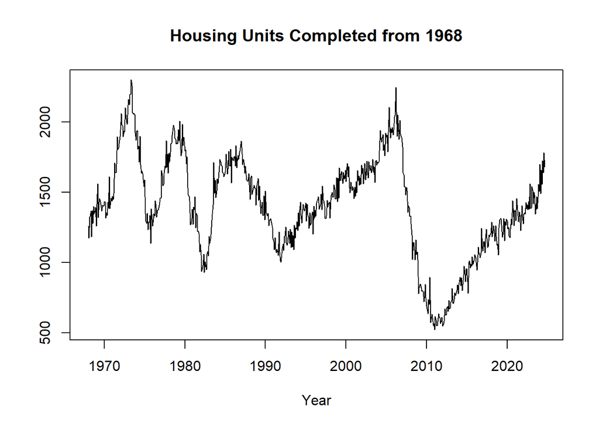

```r
huc <- huc$COMPUTSA
plot(ts(huc, frequency=12,start=c(1968,1)),xlab='Year',ylab='')
title(main='Housing Units Completed from 1968')
```

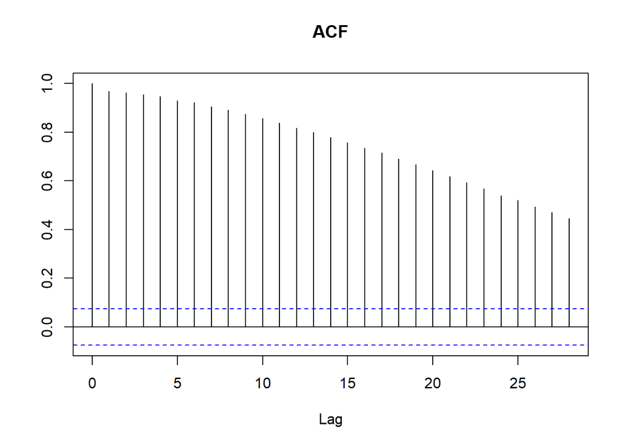

```r
acf(huc,ylab='',main='ACF')
```

```r
x = parzen.wge(huc)
```

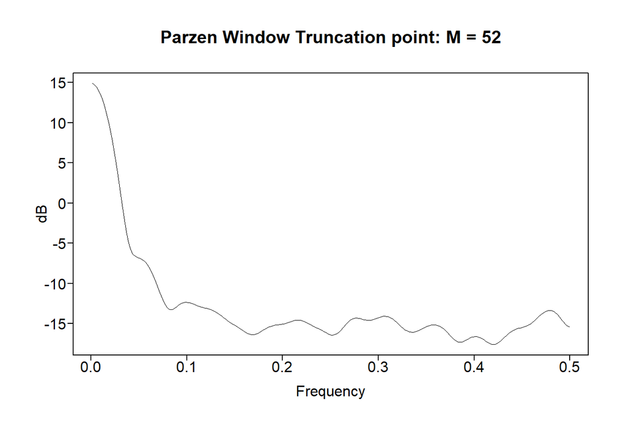

This has very similar characteristics to home ownership rate. It’s autocorrelations dampen a little more slowly, but the ACF and Parzen Window look very similar. This variable likewise shows evidence for being stationary.

## Supply of New Houses

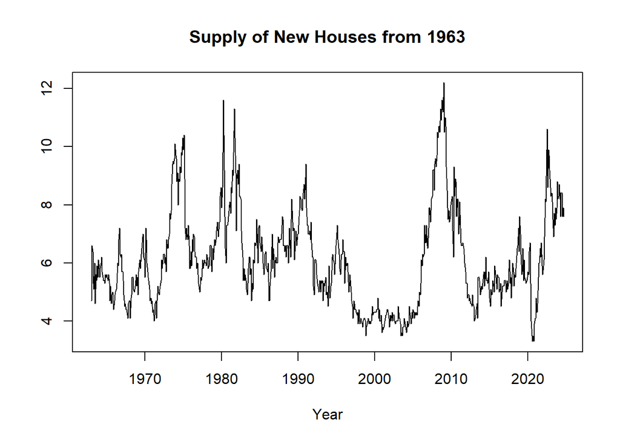

```r
snh <- snh$MSACSR
plot(ts(snh, frequency=12,start=c(1963,1)),xlab='Year',ylab='')
title(main='Supply of New Houses from 1963')
```

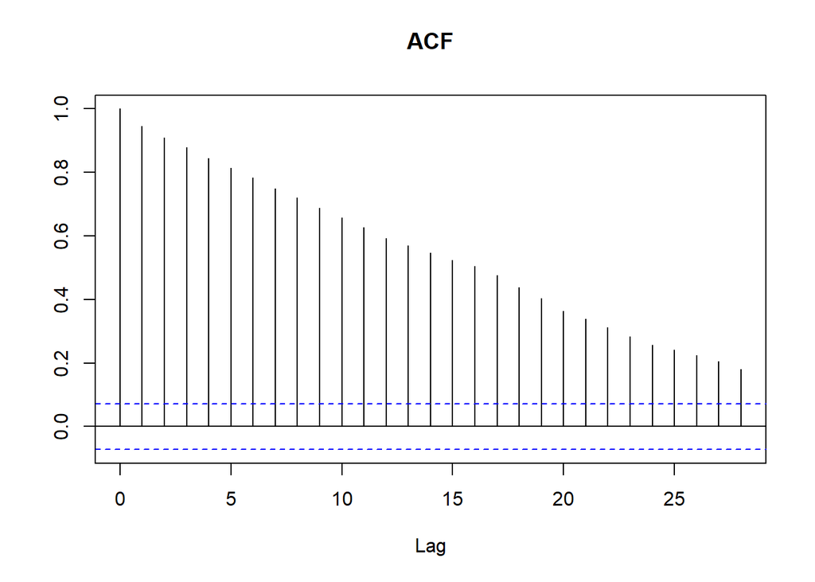

```r
acf(snh,ylab='',main='ACF')
```

```r
x = parzen.wge(snh)
```

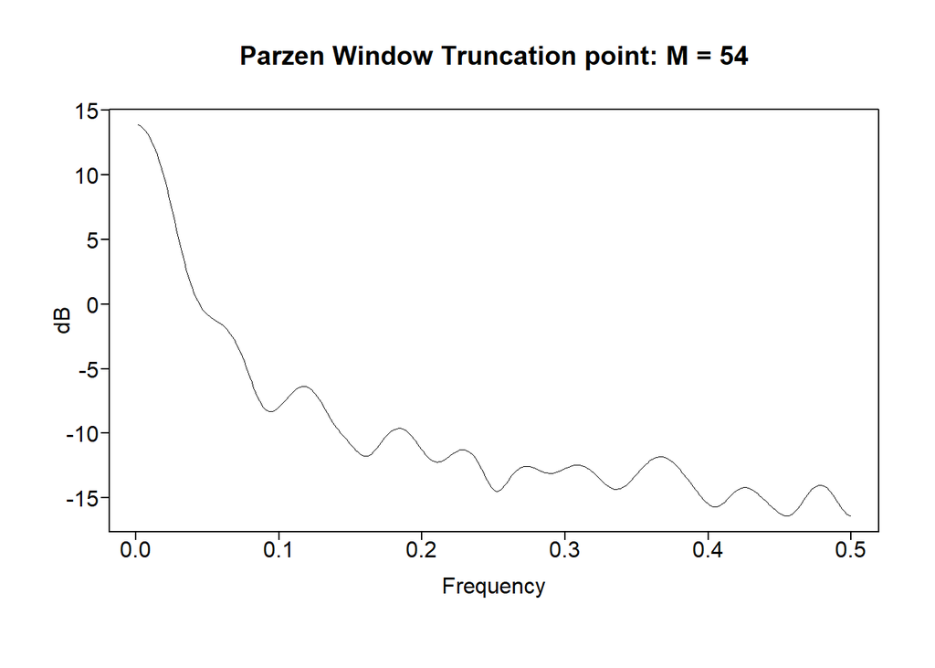

Similar to home ownership rate as well, but with even more quickly dampening autocorrelations. This variable likewise shows evidence for being stationary.

## House Price Index

The next exogenous variable is House Price Index. This was a quarterly variable, starting from 1975.

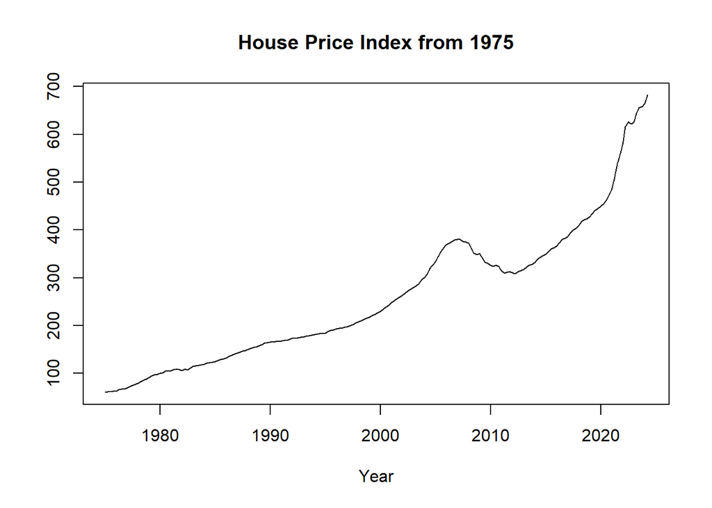

```r
hpi <- hpi$USSTHPI
plot(ts(hpi, frequency=4,start=c(1975,1)),xlab='Year',ylab='')
title(main='House Price Index from 1975')
```

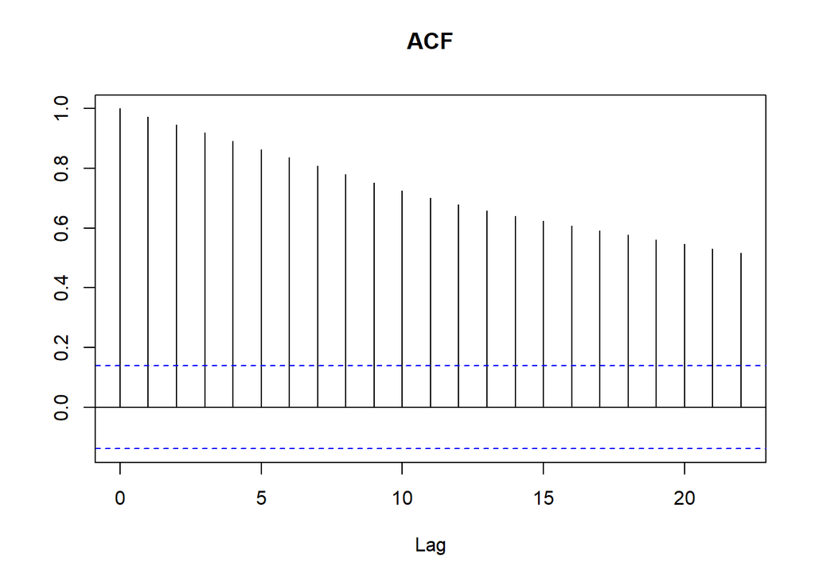

```r
acf(hpi,ylab='',main='ACF')
```

```r
x = parzen.wge(hpi)
```

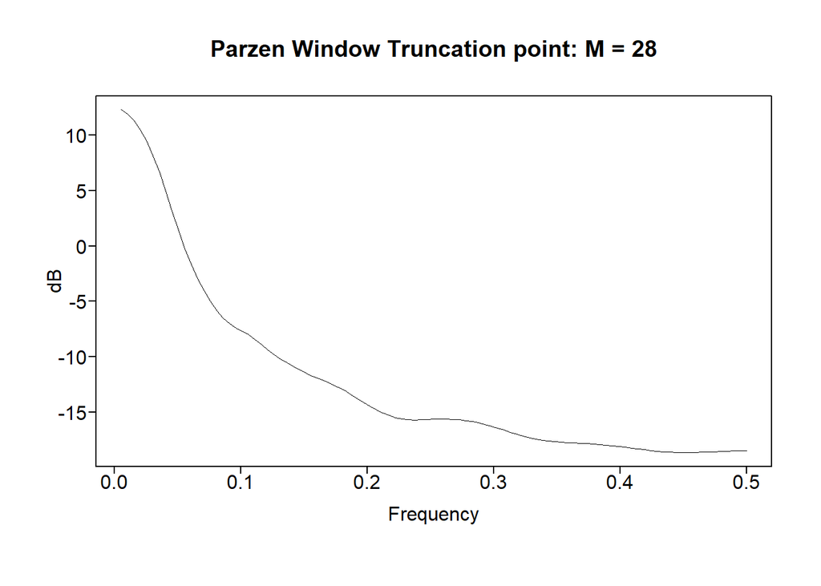

The realization has a similar upward trend to the Housing Sale Price. It seems very smooth though, very little variance. Because of the upward trend though, it shows evidence against stationarity.

The ACF and Parzen Window are also similar to those of Housing Sale Price.

Not all the data matches up by date range or by frequency of observation (monthly vs quarterly). To make everything consistent, we will only use quarterly data going from Q1 1975 to Q2 2024.

# AR(I)MA Model Investigation

## First ARIMA Model

The first model we looked at was an ARIMA model. From the EDA, we saw that because of the increasing variance, we should look at the log of the Housing Sales Price. And since the Parzen Window had a prominent peak at 0 and very slowly dampening autocorrelations, we should take the first difference.

```r
log.mhp = fed_housing_data$Median_Sales_Price
mhp = exp(log.mhp)
d.log.mhp = artrans.wge(log.mhp,1)
```

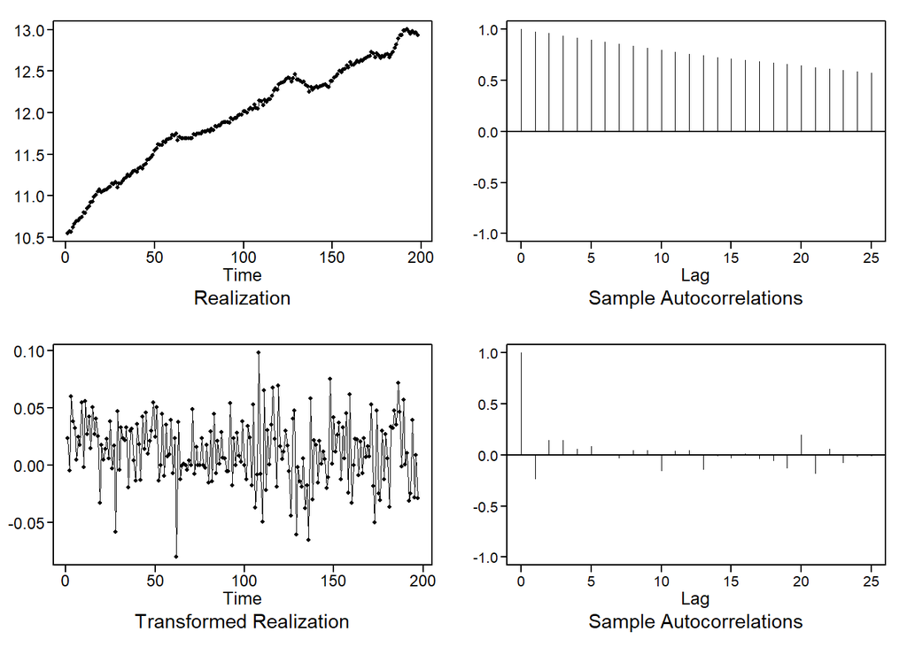

The difference looks more like white noise without an obvious pattern to the ACF. Next we will try modeling the differenced data as an ARMA model.

```r
aic5.wge(d.log.mhp,p=0:6,q=0:2,type='aic')
```

```
## ---------WORKING... PLEASE WAIT...
##
##
## Five Smallest Values of  aic
##     p    q        aic
##     1    2  -7.188559
##     2    2  -7.180263
##     5    2  -7.174131
##     3    2  -7.170135
##     6    2  -7.167230
```

```r
aic5.wge(d.log.mhp,p=0:6,q=0:2,type='bic')
```

```
## ---------WORKING... PLEASE WAIT...
##
##
## Five Smallest Values of  bic
##     p    q        bic
##     1    2  -7.121895
##     2    2  -7.096933
##     0    2  -7.092570
##     3    0  -7.087997
##     1    0  -7.087827
```

Both the AIC and BIC selection choose p = 1 and q = 2.

We will evaluate our models with a short term horizon of 1 year (4 quarters) and a long term horizon of 5 years (20 quarters). We calcluated a Rolling Window RMSE for both of those horizons (using the logged data) and calculated an ASE for both of those horizons as well (taking the exponential to get back to the original data).

```r
h.short = 4
h.long = 20
l = length(mhp)
est = est.arma.wge(d.log.mhp,p=1,q=2)
```

```
##
##
## Coefficients of AR polynomial:
## 0.6901
##
##                            AR Factor Table
## Factor                 Roots                Abs Recip    System Freq
## 1-0.6901B              1.4490               0.6901       0.0000
##
##
##
##
## Coefficients of MA polynomial:
## 0.9720 -0.4007
##
##                               MA FACTOR TABLE
## Factor                 Roots                Abs Recip    System Freq
## 1-0.9720B+0.4007B^2    1.2128+-1.0122i      0.6330       0.1107
##
##
```

```r
f = fore.arima.wge(log.mhp,d=1,phi=est$phi,theta=est$theta,n.ahead=h.short,lastn=TRUE)
```

[output not shown]

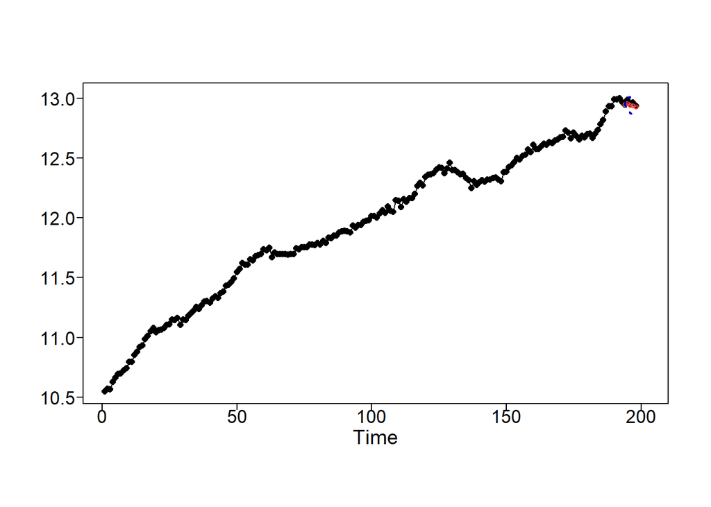

```r
ase = mean((mhp[(l-h.short+1):l]-exp(f$f))^2)/1e6
ase # 84.37902
```

```
## [1] 84.37902
```

```r
f = fore.arima.wge(log.mhp,d=1,phi=est$phi,theta=est$theta,n.ahead=h.long,lastn=TRUE)
```

[output not shown]

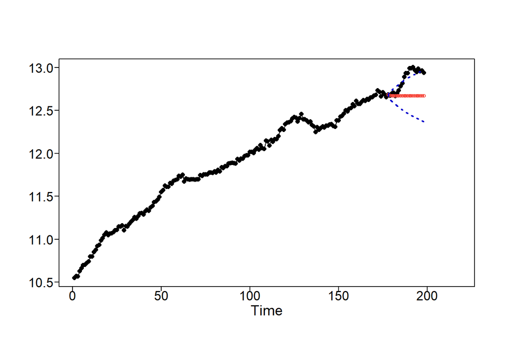

```r
ase = mean((mhp[(l-h.long+1):l]-exp(f$f))^2)/1e6
ase # 7091.032
```

```
## [1] 7091.032
```

```r
r = roll.win.rmse.wge(log.mhp,h.short,d=1,phi=est$phi,theta=est$theta) # 0.036501
```

```r
r$rwRMSE
```

```
## [1] 0.03650146
```

```r
r = roll.win.rmse.wge(log.mhp,h.long,d=1,phi=est$phi,theta=est$theta) # 0.13269
```

```r
r$rwRMSE
```

```
## [1] 0.1326872
```

For the ARIMA(1,1,2) model we get a short term Rolling Window RMSE of 0.037, a long term Rolling Window RMSE of 0.133, a short term ASE of 84.4 million and a long term ASE of 7.09 billion.

## ARMA Model

As a comparison, we wanted to look a simpler ARMA model.

```r
aic5.wge(d.log.mhp,p=0:6,q=0:4,type='aic')
```

```
## ---------WORKING... PLEASE WAIT...
##
##
## Five Smallest Values of  aic
##     p    q        aic
##     1    2  -7.188559
##     2    2  -7.180263
##     5    2  -7.174131
##     3    2  -7.170135
##     3    4  -7.168648
```

```r
aic5.wge(d.log.mhp,p=0:6,q=0:4,type='bic')
```

```
## ---------WORKING... PLEASE WAIT...
##
##
## Five Smallest Values of  bic
##     p    q        bic
##     1    2  -7.121895
##     0    3  -7.098442
##     2    2  -7.096933
##     0    2  -7.092570
##     3    0  -7.087997
```

```r
est = est.arma.wge(log.mhp,p=2,q=2)
```

```
##
##
## Coefficients of AR polynomial:
## 1.8974 -0.8977
##
##                            AR Factor Table
## Factor                 Roots                Abs Recip    System Freq
## 1-0.9972B              1.0028               0.9972       0.0000
## 1-0.9002B              1.1109               0.9002       0.0000
##
##
##
##
## Coefficients of MA polynomial:
## 1.1064 -0.4030
##
##                               MA FACTOR TABLE
## Factor                 Roots                Abs Recip    System Freq
## 1-1.1064B+0.4030B^2    1.3725+-0.7728i      0.6349       0.0816
##
##
```

```r
f = fore.arma.wge(log.mhp,phi=est$phi,theta=est$theta,n.ahead=h.short,lastn=TRUE)
```

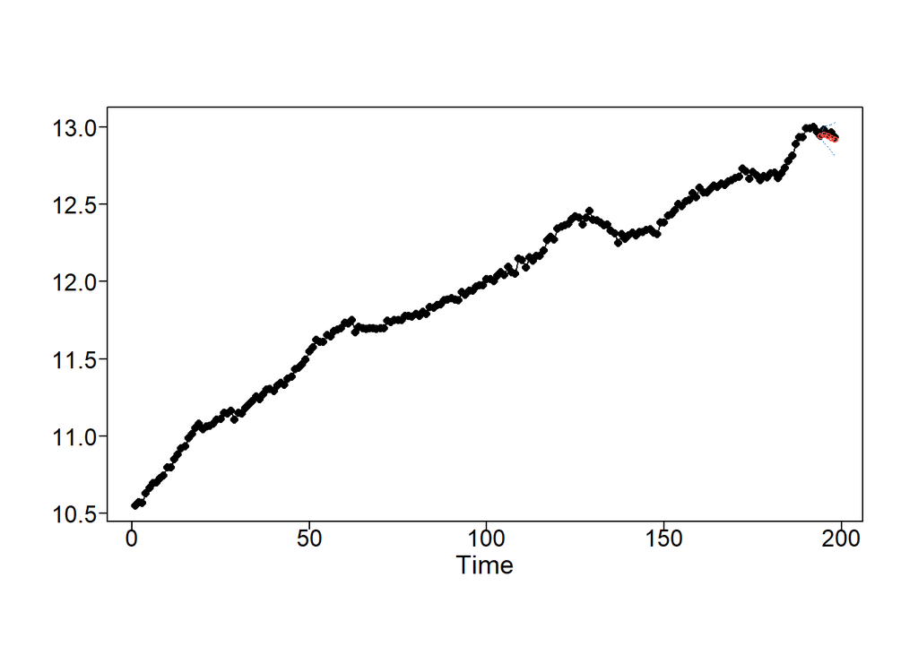

```r
ase = mean((mhp[(l-h.short+1):l]-exp(f$f))^2)/1e6
ase # 112.4314
```

```
## [1] 112.4314
```

```r
f = fore.arma.wge(log.mhp,phi=est$phi,theta=est$theta,n.ahead=h.long,lastn=TRUE)
```

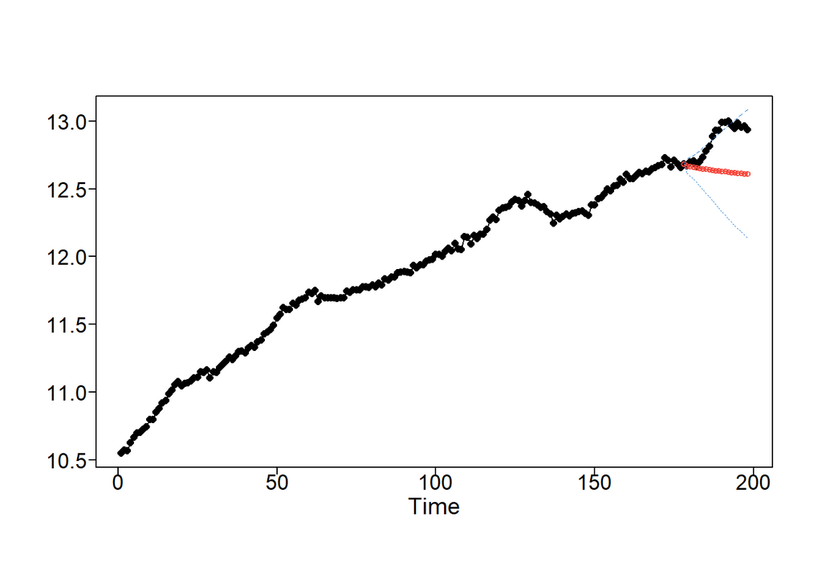

```r
ase = mean((mhp[(l-h.long+1):l]-exp(f$f))^2)/1e6
ase # 9167.59
```

```
## [1] 9167.59
```

```r
r = roll.win.rmse.wge(log.mhp,h.short,phi=est$phi,theta=est$theta) # 0.044488
```

```r
r$rwRMSE
```

```
## [1] 0.04448757
```

```r
r = roll.win.rmse.wge(log.mhp,h.long,phi=est$phi,theta=est$theta) # 0.12779
```

```r
r$rwRMSE
```

```
## [1] 0.1277888
```

For the ARMA(2,2) model we get a short term Rolling Window RMSE of 0.044, a long term Rolling Window RMSE of 0.128, a short term ASE of 112.4 million and a long term ASE of 9.17 billion. Even though this model has a better long term Rolling Window RMSE than the ARIMA model, it did worse in the other metrics.

## ARIMA(p,2,q) model

Looking at the overfit factor table, we can see two prominent 0 frequency roots.

```r
est = est.ar.wge(log.mhp,p=12)
```

```
##
##
## Coefficients of AR polynomial:
## 0.7873 0.3941 0.1201 -0.0790 -0.0881 -0.1315 -0.0324 0.0971 0.0282 -0.1868 0.0902 0.0005
##
##                            AR Factor Table
## Factor                 Roots                Abs Recip    System Freq
## 1-0.9992B              1.0008               0.9992       0.0000
## 1-0.9128B              1.0955               0.9128       0.0000
## 1+1.0481B+0.7252B^2   -0.7226+-0.9256i      0.8516       0.3555
## 1-0.0214B+0.7099B^2    0.0151+-1.1868i      0.8426       0.2480
## 1+1.5907B+0.6978B^2   -1.1398+-0.3660i      0.8353       0.4505
## 1-0.9244B+0.4855B^2    0.9519+-1.0740i      0.6968       0.1346
## 1-0.5740B              1.7420               0.5740       0.0000
## 1+0.0058B             -173.5007               0.0058       0.5000
##
##
```

```r
factor.wge(phi=est$phi)
```

```
##
##
## Coefficients of AR polynomial:
## 0.7873 0.3941 0.1201 -0.0790 -0.0881 -0.1315 -0.0324 0.0971 0.0282 -0.1868 0.0902 0.0005
##
##                            AR Factor Table
## Factor                 Roots                Abs Recip    System Freq
## 1-0.9992B              1.0008               0.9992       0.0000
## 1-0.9128B              1.0955               0.9128       0.0000
## 1+1.0481B+0.7252B^2   -0.7226+-0.9256i      0.8516       0.3555
## 1-0.0214B+0.7099B^2    0.0151+-1.1868i      0.8426       0.2480
## 1+1.5907B+0.6978B^2   -1.1398+-0.3660i      0.8353       0.4505
## 1-0.9244B+0.4855B^2    0.9519+-1.0740i      0.6968       0.1346
## 1-0.5740B              1.7420               0.5740       0.0000
## 1+0.0058B             -173.5007               0.0058       0.5000
##
##
```

Even though the differenced data didn’t have slowly dampening autocorrelations and looked liked white noise, the original data had a pretty clear upward trend. We thought that this warranted investigation into an ARIMA(p,2,q) model.

```r
d2.log.mhp = artrans.wge(d.log.mhp,1)
```

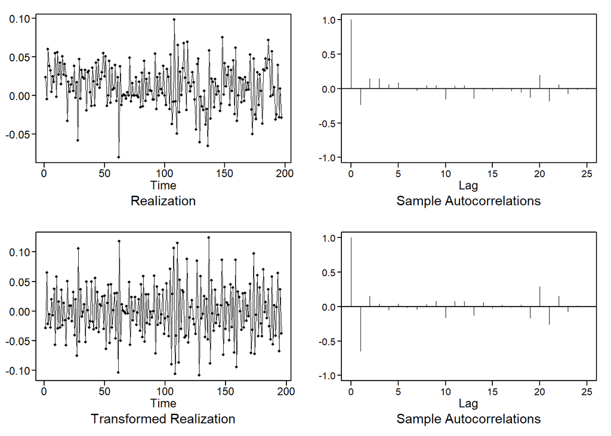

```r
aic5.wge(d.log.mhp,p=0:4,q=0:2,type='aic')
```

```
## ---------WORKING... PLEASE WAIT...
##
##
## Five Smallest Values of  aic
##     p    q        aic
##     1    2  -7.188559
##     2    2  -7.180263
##     3    2  -7.170135
##     3    1  -7.166652
##     4    0  -7.164881
```

```r
aic5.wge(d.log.mhp,p=0:4,q=0:2,type='bic')
```

```
## ---------WORKING... PLEASE WAIT...
##
##
## Five Smallest Values of  bic
##     p    q        bic
##     1    2  -7.121895
##     2    2  -7.096933
##     0    2  -7.092570
##     3    0  -7.087997
##     1    0  -7.087827
```

```r
est = est.arma.wge(d2.log.mhp,p=1,q=1)
```

```
##
##
## Coefficients of AR polynomial:
## -0.3365
##
##                            AR Factor Table
## Factor                 Roots                Abs Recip    System Freq
## 1+0.3365B             -2.9722               0.3365       0.5000
##
##
##
##
## Coefficients of MA polynomial:
## 0.8508
##
##                               MA FACTOR TABLE
## Factor                 Roots                Abs Recip    System Freq
## 1-0.8508B              1.1753               0.8508       0.0000
##
##
```

```r
f = fore.arima.wge(log.mhp,d=2,phi=est$phi,theta=est$theta,n.ahead=h.short,lastn=TRUE)
```

```
## y.arma -0.02848876 0.06515941 -0.02191816 -0.00591316 -0.02767201 0.01995818 -0.007043221 0.0372058 -0.05668252 0.05783844 -0.02902112 0.01571075 -0.02811809 0.03603873 -0.02364418 0.01366843 -0.01538544 -0.05803636 0.05041521 -0.01272076 0.00926602 0.008884892 -0.01684341 0.03217776 -0.04106979 …
```

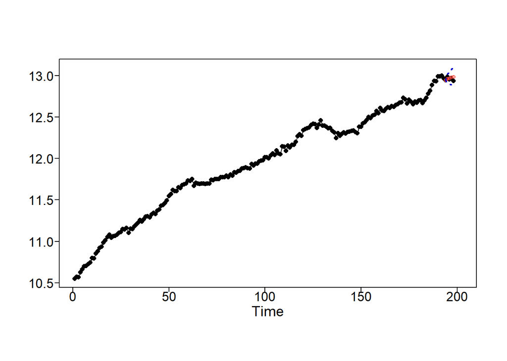

```r
ase = mean((mhp[(l-h.short+1):l]-exp(f$f))^2)/1e6
ase # 162.1383
```

```
## [1] 162.1383
```

```r
f = fore.arima.wge(log.mhp,d=2,phi=est$phi,theta=est$theta,n.ahead=h.long,lastn=TRUE)
```

```
## y.arma -0.02848876 0.06515941 -0.02191816 -0.00591316 -0.02767201 0.01995818 -0.007043221 0.0372058 -0.05668252 0.05783844 -0.02902112 0.01571075 -0.02811809 0.03603873 -0.02364418 0.01366843 -0.01538544 -0.05803636 0.05041521 -0.01272076 0.00926602 0.008884892 -0.01684341 0.03217776 -0.04106979 …
```

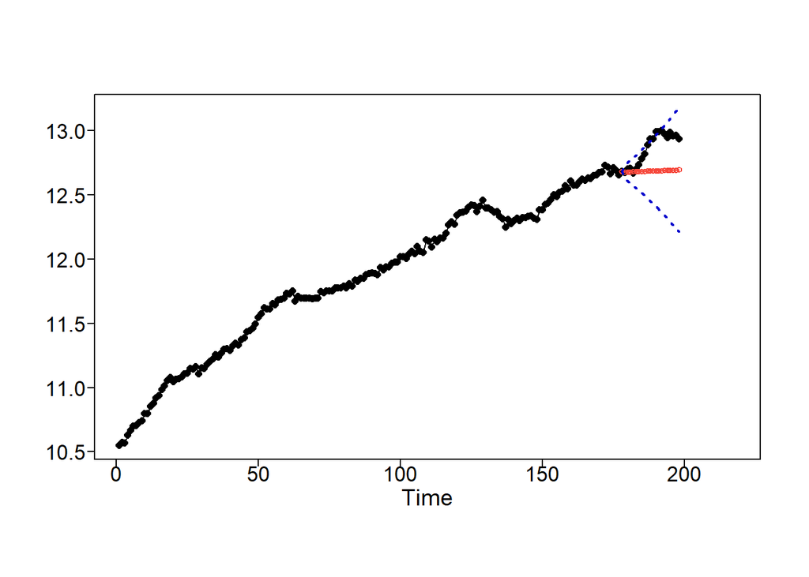

```r
ase = mean((mhp[(l-h.long+1):l]-exp(f$f))^2)/1e6
ase # 6263.556
```

```
## [1] 6263.556
```

```r
r = roll.win.rmse.wge(log.mhp,h.short,d=2,phi=est$phi,theta=est$theta) # 0.049161
```

```r
r$rwRMSE
```

```
## [1] 0.0491605
```

```r
r = roll.win.rmse.wge(log.mhp,h.long,d=2,phi=est$phi,theta=est$theta) # 0.1809277
```

```r
r$rwRMSE
```

```
## [1] 0.1809277
```

Comparing all three ARMA/ARIMA models, we will choose the ARIMA(1,1,2).

```r
est = est.arma.wge(d.log.mhp,p=1,q=2)
```

```
##
##
## Coefficients of AR polynomial:
## 0.6901
##
##                            AR Factor Table
## Factor                 Roots                Abs Recip    System Freq
## 1-0.6901B              1.4490               0.6901       0.0000
##
##
##
##
## Coefficients of MA polynomial:
## 0.9720 -0.4007
##
##                               MA FACTOR TABLE
## Factor                 Roots                Abs Recip    System Freq
## 1-0.9720B+0.4007B^2    1.2128+-1.0122i      0.6330       0.1107
##
##
```

```r
f = fore.arima.wge(log.mhp,d=1,phi=est$phi,theta=est$theta,n.ahead=h.short,lastn=TRUE)
```

```
## y.arma 0.02334736 -0.0051414 0.06001801 0.03809985 0.03218669 0.00451468 0.02447286 0.01742964 0.05463544 -0.002047084 0.05579136 0.02677024 0.04248099 0.0143629 0.05040163 0.02675745 0.04042588 0.02504043 -0.03299592 0.01741928 0.004698521 0.01396454 0.02284943 0.006006024 0.03818379 -0.00288600…
```

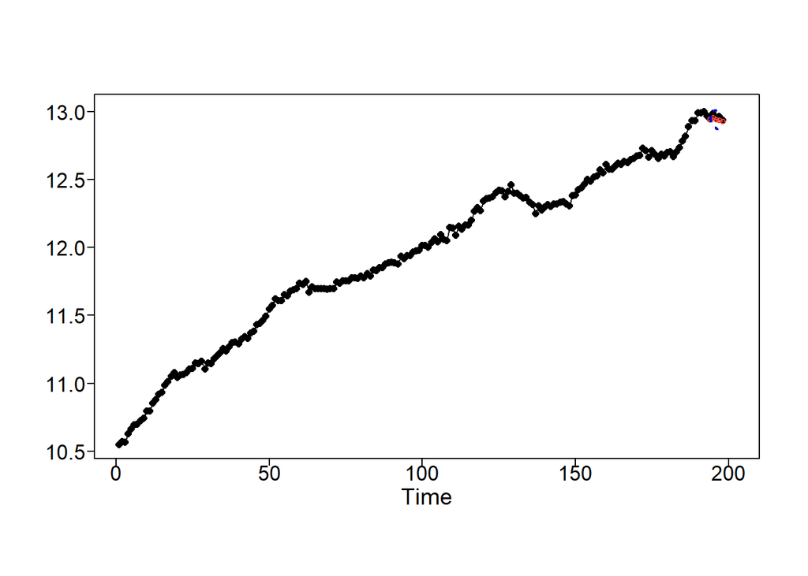

```r
aic = est$aic
aic # -7.188559
```

```
## [1] -7.188559
```

```r
resid = f$resid
xbar=est$xbar
xbar # 0.01211603
```

```
## [1] 0.01211603
```

```r
vara = est$avar
vara # 0.0007251235
```

```
## [1] 0.0007251235
```

```r
est$phi # 0.6901326
```

```
## [1] 0.6901326
```

```r
est$theta # 0.9720137 -0.4007360
```

```
## [1]  0.9720137 -0.4007360
```

The model (for the log data) can be written as: (1-B)(1-0.69B)(x_t-0.012) = (1-0.972B+0.401B^2)a_t $\sigma$_t^2 = 0.001

Now we will look at residuals to make sure that they are white noise.

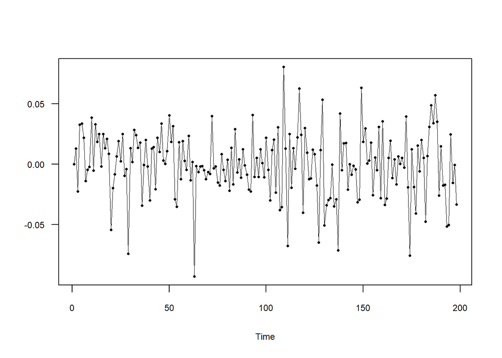

```r
plotts.wge(resid)
```

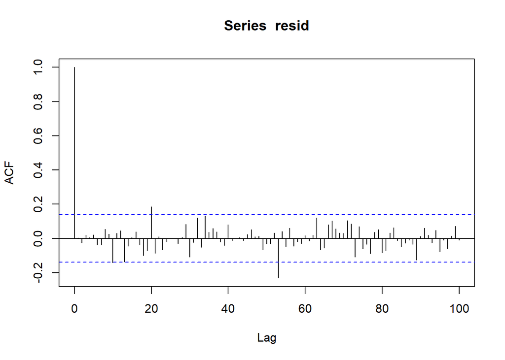

```r
acf(resid,lag.max=100)
```

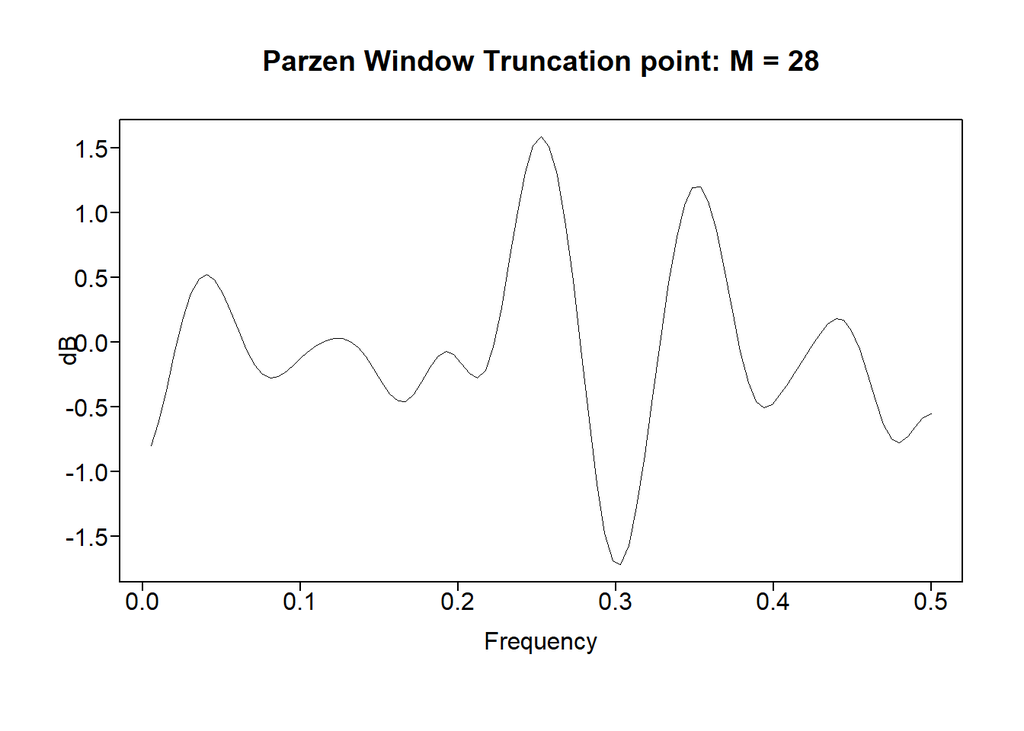

[output not shown]

[output cut: 25 more lines]

```r
parzen.wge(resid)
```

They appear to be white noise, and the ACF has very few values above 0.2. We will run a Ljung-Box test to be sure.

```r
ljung.wge(resid,K=24,p=1,q=2) # p = 0.2272667, white
```

```
## Obs 0.00435293 -0.0244108 0.01796347 0.005240047 0.02127357 -0.03888973 -0.03903064 0.05468715 0.02530515 -0.142211 0.02934427 0.04507912 -0.1378715 -0.04501699 0.006830995 0.0376424 -0.03877854 -0.09888204 -0.07092551 0.1855184 -0.08752274 0.009655451 -0.06740214 -0.01970965
```

```
## $test
## [1] "Ljung-Box test"
##
## $K
## [1] 24
##
## $chi.square
## [1] 25.47283
##
## $df
## [1] 21
##
## $pval
## [1] 0.2272667
```

```r
ljung.wge(resid,K=48,p=1,q=2) # p = 0.5584003, white
```

```
## Obs 0.00435293 -0.0244108 0.01796347 0.005240047 0.02127357 -0.03888973 -0.03903064 0.05468715 0.02530515 -0.142211 0.02934427 0.04507912 -0.1378715 -0.04501699 0.006830995 0.0376424 -0.03877854 -0.09888204 -0.07092551 0.1855184 -0.08752274 0.009655451 -0.06740214 -0.01970965 0.0001776949 -0.0020…
```

```
## $test
## [1] "Ljung-Box test"
##
## $K
## [1] 48
##
## $chi.square
## [1] 42.96777
##
## $df
## [1] 45
##
## $pval
## [1] 0.5584003
```

The test gives more evidence that the residuals are white noise. We can also check if they are normally distributed with a histogram.

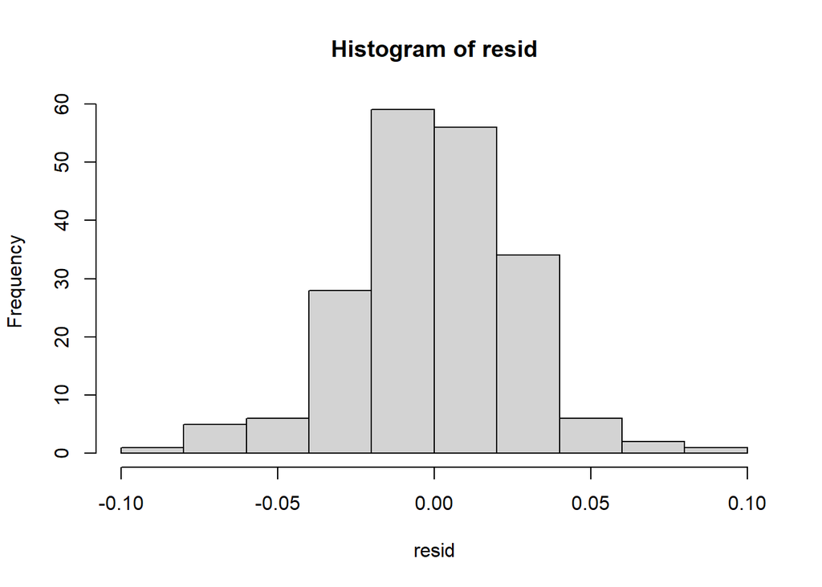

```r
hist(resid)
```

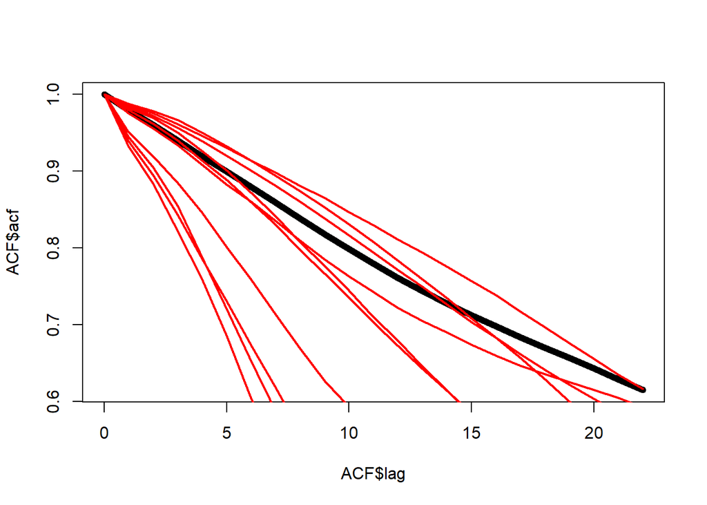

```r
# Multiple ACFs
set.seed(2)
sims = 10
ACF = acf(log.mhp, plot = "FALSE")
plot(ACF$lag ,ACF$acf , type = "l", lwd = 6)
for( i in 1: sims)
{
  ACF2 = acf(gen.arima.wge(l, phi = est$phi, theta=est$theta,d=1, plot="FALSE"), plot = "FALSE")
  lines(ACF2$lag ,ACF2$acf, lwd = 2, col = "red")
}
```

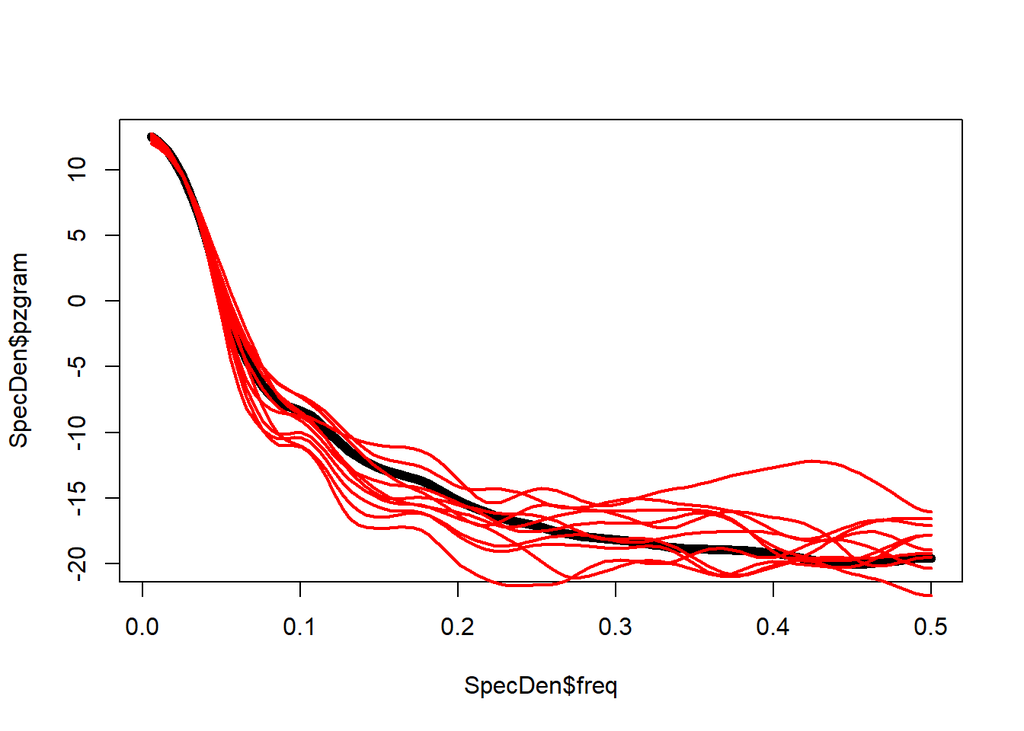

```r
# Multiple Parzen
set.seed(3)
sims = 10
SpecDen = parzen.wge(log.mhp, plot = "FALSE")
plot(SpecDen$freq,SpecDen$pzgram, type = "l", lwd = 6)
for( i in 1: sims)
{
  SpecDen2 = parzen.wge(gen.aruma.wge(l,phi=est$phi, theta=est$theta,d=1, plot ="FALSE"), plot = "FALSE")
  lines(SpecDen2$freq,SpecDen2$pzgram, lwd = 2, col = "red")
}
```

The ACFs don’t match up exactly, but have the same slowly dampening behavior. The Parzen Windows are very close to the original.

# Exogenous Variable Forecasts

In order to use the Exogenous variables in either the MLR or Multi-Variate MLP, it is more realistic to make predictions for them first.

For error metrics, we will focus on the ASE for short and long term predictions. This is because we are specifically using these short and long term predictions in future models.

## Home Ownership Rate

The Home Ownership Rate looked like either an ARMA or an ARIMA(p,1,q) might be appropriate.

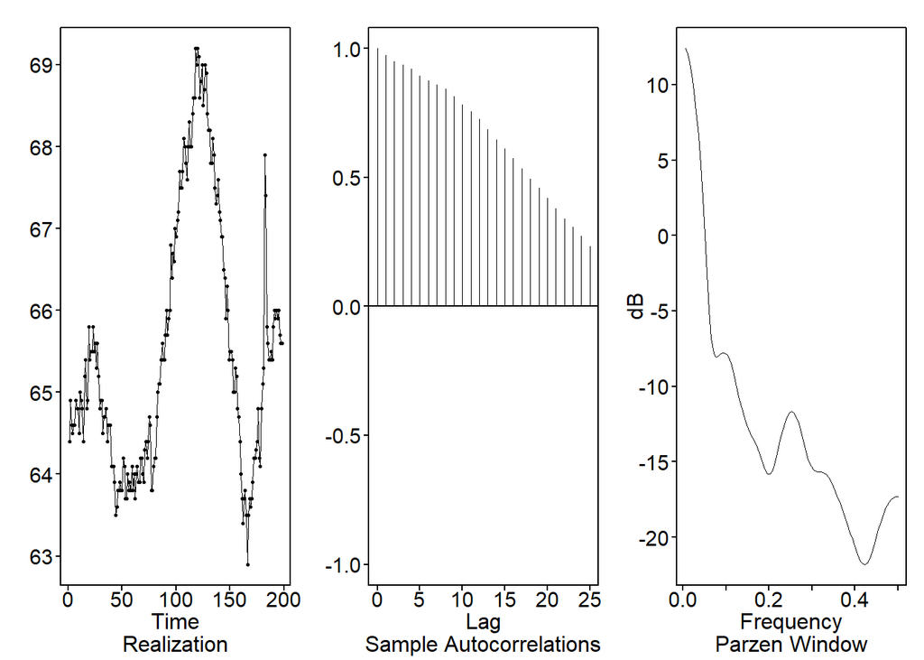

[output not shown]

[output cut: 34 more lines]

```r
x = fed_housing_data$Ownership_Rate
plotts.sample.wge(x)
```

```r
d = artrans.wge(x,1)
```

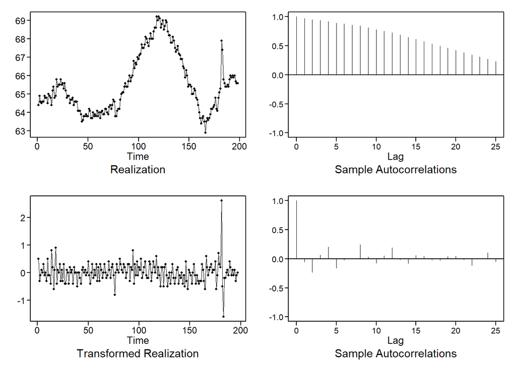

We will start with the ARIMA model.

```r
aic5.wge(d,p=0:10,q=0:4,type='aic') # 8/1 best
```

```
## ---------WORKING... PLEASE WAIT...
##
##
## Error in aic calculation at 6 4
## Five Smallest Values of  aic
##     p    q        aic
##     8    1  -2.113107
##     8    0  -2.111537
##     9    0  -2.108892
##     8    2  -2.105050
##     8    3  -2.103671
```

The model with the best AIC is p = 8, q = 1.

```r
est = est.arma.wge(d,p=8,q=1)
```

```
##
##
## Coefficients of AR polynomial:
## 0.5294 -0.2041 0.1820 0.1108 -0.2424 0.1690 -0.1057 0.2697
##
##                            AR Factor Table
## Factor                 Roots                Abs Recip    System Freq
## 1-0.9134B              1.0948               0.9134       0.0000
## 1+0.8712B             -1.1478               0.8712       0.5000
## 1-1.3170B+0.7430B^2    0.8862+-0.7486i      0.8620       0.1116
## 1-0.0293B+0.7263B^2    0.0202+-1.1733i      0.8522       0.2473
## 1+0.8591B+0.6281B^2   -0.6839+-1.0604i      0.7925       0.3412
##
##
##
##
## Coefficients of MA polynomial:
## 0.5818
##
##                               MA FACTOR TABLE
## Factor                 Roots                Abs Recip    System Freq
## 1-0.5818B              1.7189               0.5818       0.0000
##
##
```